# Data Camp / ARIMA Modeling with R - Chapter 3

Initialize and load the data

```r
library(astsa)
library(xts)
```

Chapter 3 of [Data Camp - ARIMA Modeling with R](https://www.datacamp.com/courses/arima-modeling-with-r)

# ARIMA (Integrated ARMA models)

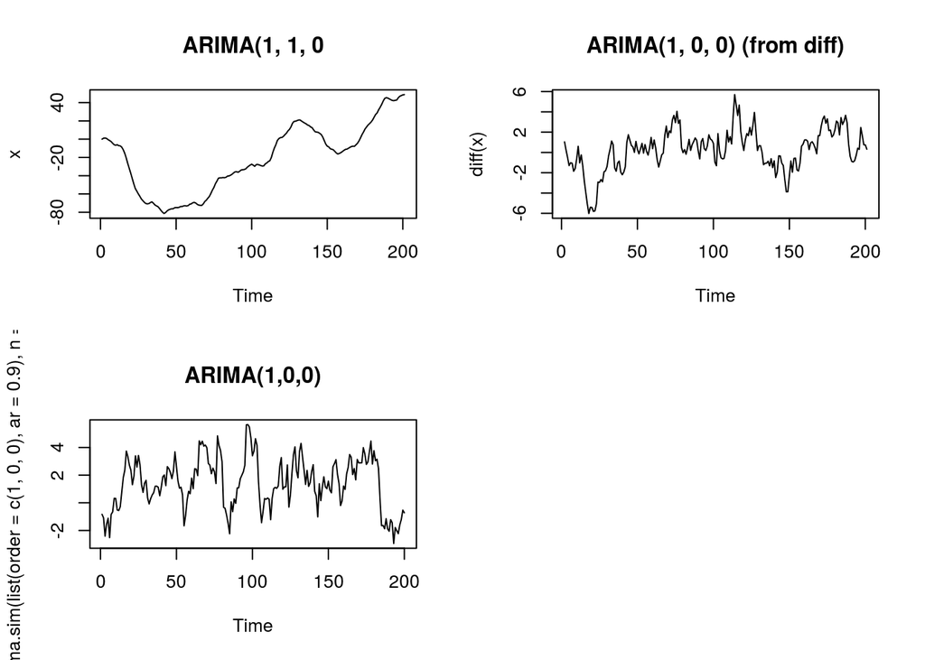

```r
x <- arima.sim(list(order=c(1,1,0), ar=0.9), n=200)

par(mfrow=c(2,2))
plot(x, main='ARIMA(1, 1, 0')
plot(diff(x), main='ARIMA(1, 0, 0) (from diff)')
plot(arima.sim(list(order=c(1,0,0), ar=0.9), n=200),
     main='ARIMA(1,0,0)')
```

## ACF and PACF for integrated models

**ACF** decays in a liear fasion **PACF** is almost 1 at lag1

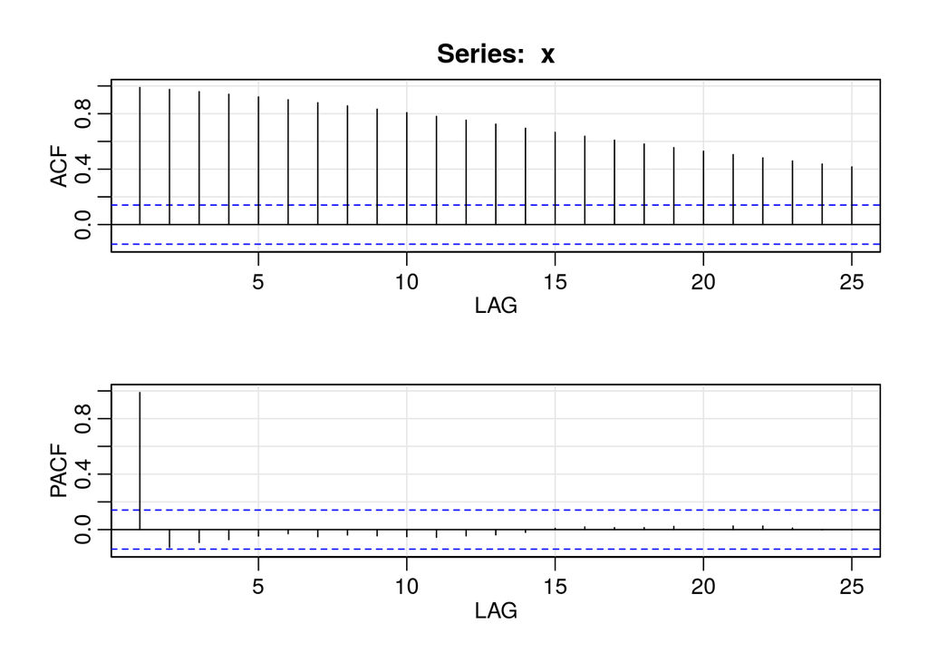

```
##        ACF  PACF
##  [1,] 0.99  0.99
##  [2,] 0.97 -0.13
##  [3,] 0.96 -0.09
##  [4,] 0.94 -0.07
##  [5,] 0.92 -0.05
##  [6,] 0.90 -0.03
##  [7,] 0.88 -0.05
##  [8,] 0.86 -0.04
##  [9,] 0.83 -0.04
## [10,] 0.81 -0.05
## [11,] 0.78 -0.06
## [12,] 0.75 -0.05
## [13,] 0.72 -0.04
## [14,] 0.69 -0.02
## [15,] 0.67  0.01
## [16,] 0.64  0.02
## [17,] 0.61  0.01
## [18,] 0.58  0.01
## [19,] 0.56  0.02
## [20,] 0.53  0.00
## [21,] 0.50  0.03
## [22,] 0.48  0.03
## [23,] 0.46  0.01
## [24,] 0.44  0.00
## [25,] 0.42  0.00
```

```r
acf2(x)
```

After differencing they look like for **ARMA** models.

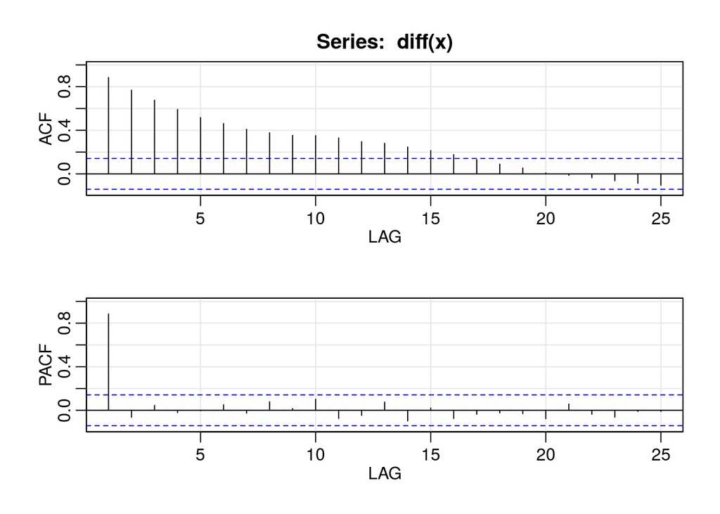

```
##         ACF  PACF
##  [1,]  0.88  0.88
##  [2,]  0.77 -0.06
##  [3,]  0.68  0.05
##  [4,]  0.59 -0.02
##  [5,]  0.52  0.00
##  [6,]  0.46  0.05
##  [7,]  0.41 -0.03
##  [8,]  0.38  0.08
##  [9,]  0.35  0.02
## [10,]  0.35  0.10
## [11,]  0.33 -0.07
## [12,]  0.30 -0.05
## [13,]  0.28  0.08
## [14,]  0.25 -0.10
## [15,]  0.21  0.02
## [16,]  0.18 -0.07
## [17,]  0.13 -0.04
## [18,]  0.09 -0.02
## [19,]  0.05 -0.03
## [20,]  0.01 -0.08
## [21,] -0.01  0.06
## [22,] -0.04 -0.04
## [23,] -0.06 -0.06
## [24,] -0.09 -0.01
## [25,] -0.10 -0.01
```

```r
acf2(diff(x))
```

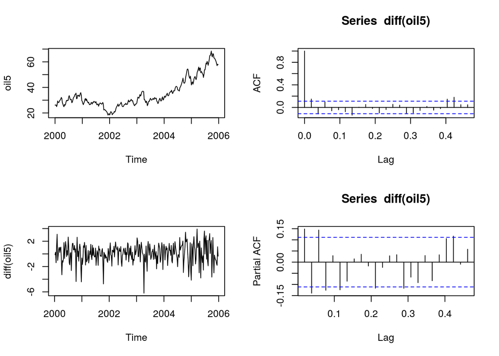

```r
oil5 <- window(oil, end=c(2005, 52))
par(mfcol=c(2,2))
plot(oil5)
plot(diff(oil5))
acf(diff(oil5))
pacf(diff(oil5))
```

The data appear to be MA so differencing is appropriate. The differenced data appear to be stationary so an ARMA(1,0,1) is valid on the difference data or ARIMA(1,1,1) are appropriate models to try.

```r
arima(x, order=c(1,1,1)) -> a1
arima(diff(x), order=c(1,0,1)) -> a2

print(a1)
```

```
##
## Call:
## arima(x = x, order = c(1, 1, 1))
##
## Coefficients:
##          ar1     ma1
##       0.8651  0.0817
## s.e.  0.0394  0.0836
##
## sigma^2 estimated as 0.9112:  log likelihood = -275.25,  aic = 556.51
```

```r
print(a2)
```

```
##
## Call:
## arima(x = diff(x), order = c(1, 0, 1))
##
## Coefficients:
##          ar1     ma1  intercept
##       0.8628  0.0828     0.2703
## s.e.  0.0397  0.0837     0.5163
##
## sigma^2 estimated as 0.9101:  log likelihood = -275.12,  aic = 558.23
```

## ARIMA - Plug and Play

A time series is called **ARIMA(1,1,1)** if the *difference series* of order *d* is *ARMA(1, 0, 1)*

## Messin’ around with stuff

```r
x <= arima.sim(model=list(order=c(0,1,2), ma=c(1.2,0.7)), n=200)
```

[output not shown]

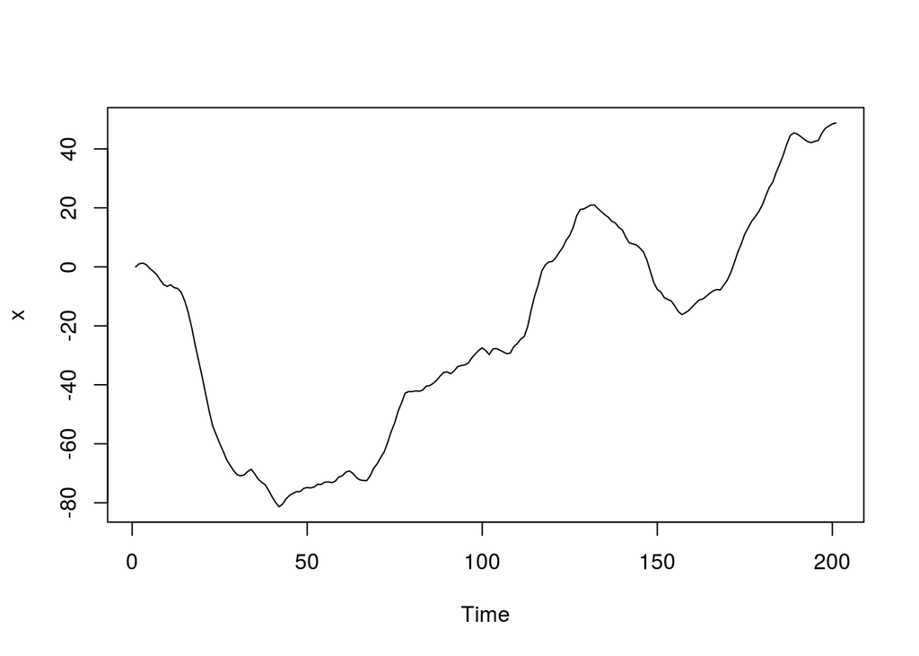

```r
plot(x)
```

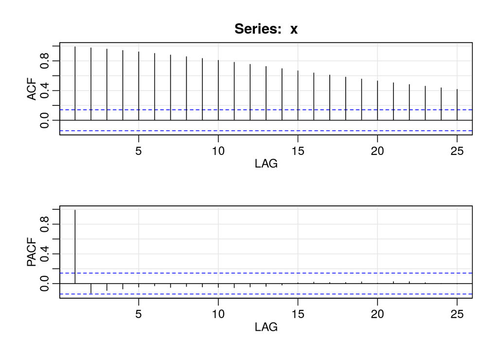

```
##        ACF  PACF
##  [1,] 0.99  0.99
##  [2,] 0.97 -0.13
##  [3,] 0.96 -0.09
##  [4,] 0.94 -0.07
##  [5,] 0.92 -0.05
##  [6,] 0.90 -0.03
##  [7,] 0.88 -0.05
##  [8,] 0.86 -0.04
##  [9,] 0.83 -0.04
## [10,] 0.81 -0.05
## [11,] 0.78 -0.06
## [12,] 0.75 -0.05
## [13,] 0.72 -0.04
## [14,] 0.69 -0.02
## [15,] 0.67  0.01
## [16,] 0.64  0.02
## [17,] 0.61  0.01
## [18,] 0.58  0.01
## [19,] 0.56  0.02
## [20,] 0.53  0.00
## [21,] 0.50  0.03
## [22,] 0.48  0.03
## [23,] 0.46  0.01
## [24,] 0.44  0.00
## [25,] 0.42  0.00
```

```r
acf2(x)
```

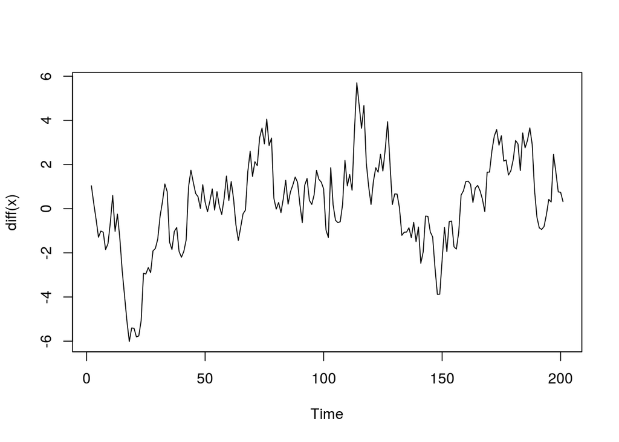

```r
plot(diff(x))
```

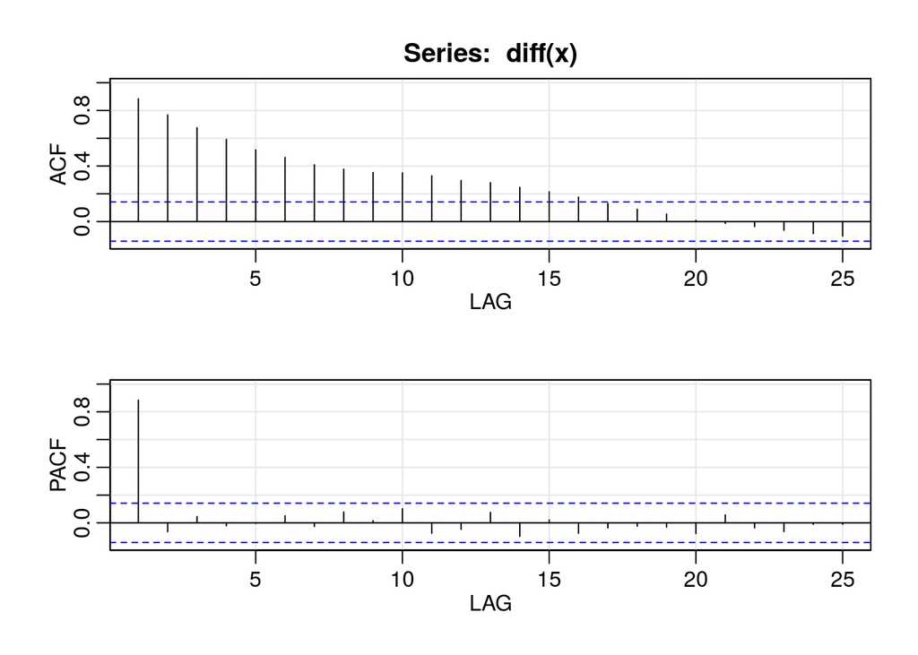

```
##         ACF  PACF
##  [1,]  0.88  0.88
##  [2,]  0.77 -0.06
##  [3,]  0.68  0.05
##  [4,]  0.59 -0.02
##  [5,]  0.52  0.00
##  [6,]  0.46  0.05
##  [7,]  0.41 -0.03
##  [8,]  0.38  0.08
##  [9,]  0.35  0.02
## [10,]  0.35  0.10
## [11,]  0.33 -0.07
## [12,]  0.30 -0.05
## [13,]  0.28  0.08
## [14,]  0.25 -0.10
## [15,]  0.21  0.02
## [16,]  0.18 -0.07
## [17,]  0.13 -0.04
## [18,]  0.09 -0.02
## [19,]  0.05 -0.03
## [20,]  0.01 -0.08
## [21,] -0.01  0.06
## [22,] -0.04 -0.04
## [23,] -0.06 -0.06
## [24,] -0.09 -0.01
## [25,] -0.10 -0.01
```

```r
acf2(diff(x))
```

## Excersize with Global Temp data

### Just a reminder …

- Random Walk > This model assumes that in each period the variable takes a random step away from its previous value, and the steps are independently and identically distributed in size (“i.i.d.”). This is equivalent to saying that the first difference of the variable is a series to which the mean model should be applied.

Using Average Global temps from 1880 - 2015. This data appears to be Random Walk (see above for definition.) So, Differencing this will remove trend and provide a stationary series.

After taking the ACF of the differenced data there are 3 options for modesl:

- ACF and PACF both trail off so ARIMA(1,1,1)
- ACF cuts off at lag2 and PACF trails off so ARIMA(0,1,2)
- ACF trails off and PACF cuts off at lag 3, so ARIMA(3,1,0) [Not a good candidate because too complicated for such a simple datasets]

**Note**: The degree of the model is dependant on where the PACF cuts off, when it does.

So, we model the first 2 with `sarima()`

The residual analysis is a little better for the ARIMA(0,1,2) although the AIC and BIC are slighly larger for the ARIMA(1,1,1). Either model is good, I would take the ARIMA(0,1,2) though, due to the residual analysis “looking” better to me.

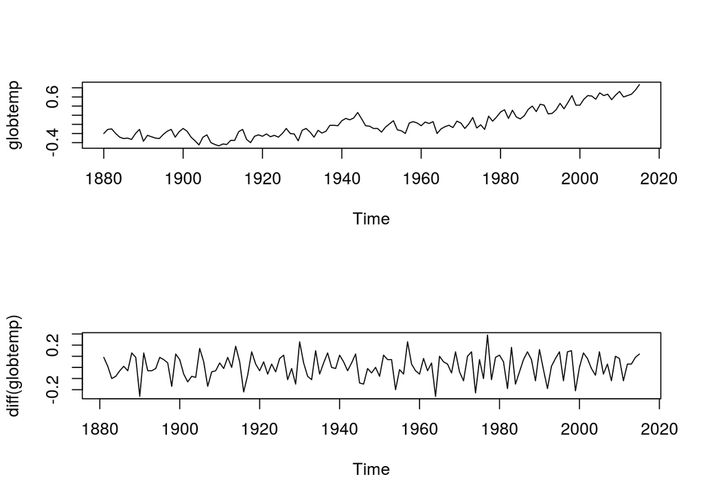

```r
par(mfrow=c(2,1))
plot(globtemp)
plot(diff(globtemp))
```

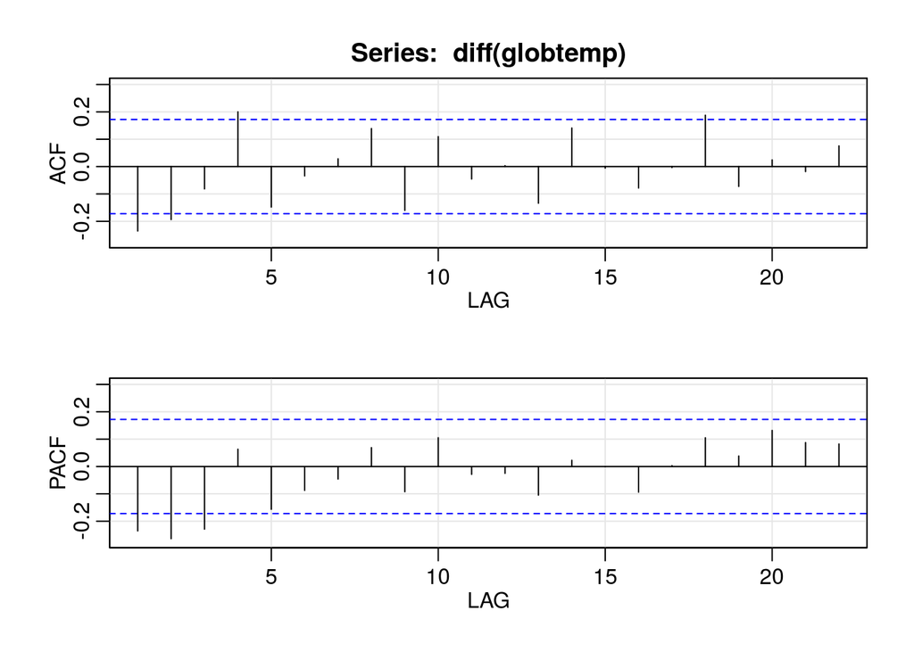

```
##         ACF  PACF
##  [1,] -0.24 -0.24
##  [2,] -0.19 -0.26
##  [3,] -0.08 -0.23
##  [4,]  0.20  0.06
##  [5,] -0.15 -0.16
##  [6,] -0.03 -0.09
##  [7,]  0.03 -0.05
##  [8,]  0.14  0.07
##  [9,] -0.16 -0.09
## [10,]  0.11  0.11
## [11,] -0.05 -0.03
## [12,]  0.00 -0.02
## [13,] -0.13 -0.10
## [14,]  0.14  0.02
## [15,] -0.01  0.00
## [16,] -0.08 -0.09
## [17,]  0.00  0.00
## [18,]  0.19  0.11
## [19,] -0.07  0.04
## [20,]  0.02  0.13
## [21,] -0.02  0.09
## [22,]  0.08  0.08
```

```r
acf2(diff(globtemp))
```

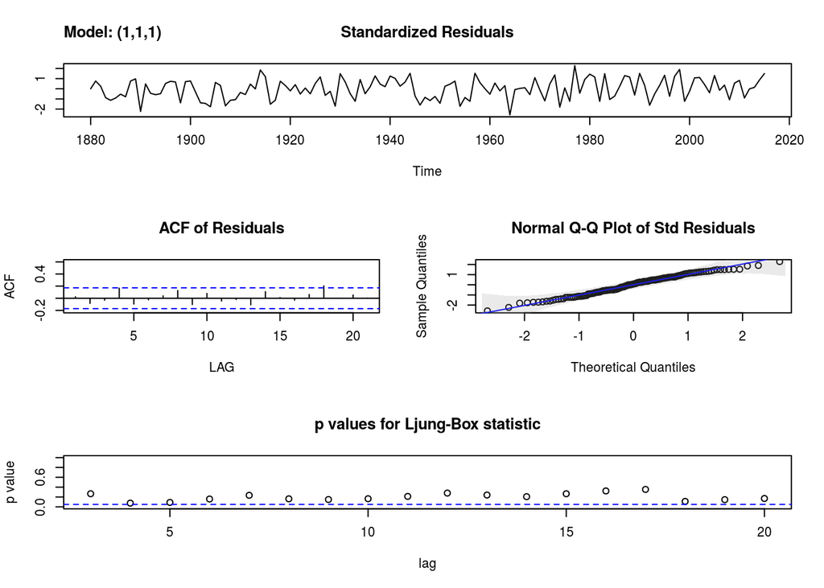

```
## $fit
##
## Call:
## stats::arima(x = xdata, order = c(p, d, q), seasonal = list(order = c(P, D,
##     Q), period = S), xreg = constant, optim.control = list(trace = trc, REPORT = 1,
##     reltol = tol))
##
## Coefficients:
##          ar1      ma1  constant
##       0.3549  -0.7663    0.0072
## s.e.  0.1314   0.0874    0.0032
##
## sigma^2 estimated as 0.009885:  log likelihood = 119.88,  aic = -231.76
##
## $degrees_of_freedom
## [1] 133
##
## $ttable
##          Estimate     SE t.value p.value
## ar1        0.3549 0.1314  2.7008  0.0078
## ma1       -0.7663 0.0874 -8.7701  0.0000
## constant   0.0072 0.0032  2.2738  0.0246
##
## $AIC
## [1] -3.572642
##
## $AICc
## [1] -3.555691
##
## $BIC
## [1] -4.508392
```

```r
sarima(globtemp, 1, 1, 1)
```

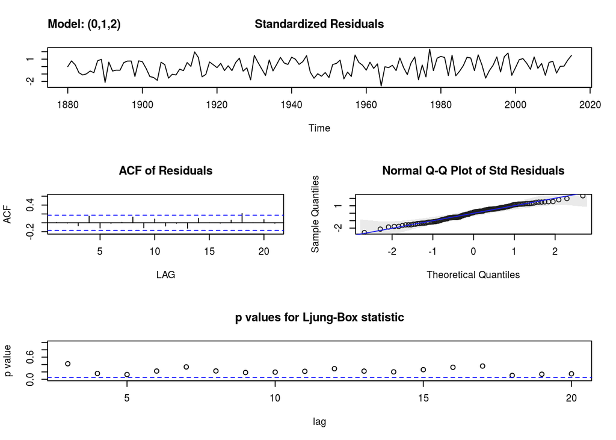

```
## $fit
##
## Call:
## stats::arima(x = xdata, order = c(p, d, q), seasonal = list(order = c(P, D,
##     Q), period = S), xreg = constant, optim.control = list(trace = trc, REPORT = 1,
##     reltol = tol))
##
## Coefficients:
##           ma1      ma2  constant
##       -0.3984  -0.2173    0.0072
## s.e.   0.0808   0.0768    0.0033
##
## sigma^2 estimated as 0.00982:  log likelihood = 120.32,  aic = -232.64
##
## $degrees_of_freedom
## [1] 133
##
## $ttable
##          Estimate     SE t.value p.value
## ma1       -0.3984 0.0808 -4.9313  0.0000
## ma2       -0.2173 0.0768 -2.8303  0.0054
## constant   0.0072 0.0033  2.1463  0.0337
##
## $AIC
## [1] -3.579224
##
## $AICc
## [1] -3.562273
##
## $BIC
## [1] -4.514974
```

```r
sarima(globtemp, 0, 1, 2)
```

### Shits and Giggles

Just because I can, model against the ARIMA(3,1,0) just to see what happens. In this case both the residual analysis AND the AIC/BIC are reasonably good. **BUT** dont forget

> AIC and BIC help you find the model with the smallest error using the least number of parameters. The idea is based on the *parsimony principle*, which is basic to all science and tells you to choose the simplest scientific explanation that fits the evidence.

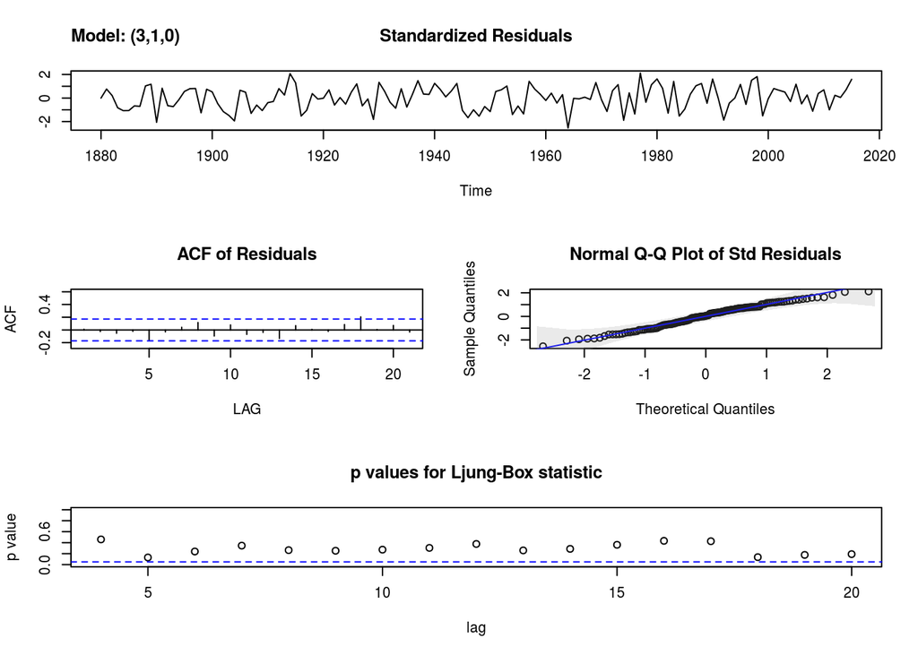

```
## $fit
##
## Call:
## stats::arima(x = xdata, order = c(p, d, q), seasonal = list(order = c(P, D,
##     Q), period = S), xreg = constant, optim.control = list(trace = trc, REPORT = 1,
##     reltol = tol))
##
## Coefficients:
##           ar1      ar2      ar3  constant
##       -0.3669  -0.3421  -0.2363    0.0071
## s.e.   0.0842   0.0849   0.0838    0.0044
##
## sigma^2 estimated as 0.009733:  log likelihood = 120.93,  aic = -231.85
##
## $degrees_of_freedom
## [1] 132
##
## $ttable
##          Estimate     SE t.value p.value
## ar1       -0.3669 0.0842 -4.3592  0.0000
## ar2       -0.3421 0.0849 -4.0319  0.0001
## ar3       -0.2363 0.0838 -2.8186  0.0056
## constant   0.0071 0.0044  1.6168  0.1083
##
## $AIC
## [1] -3.573377
##
## $AICc
## [1] -3.555277
##
## $BIC
## [1] -4.487711
```

```r
sarima(globtemp, 3, 1, 0)
```

## ARIMA Diagnostics

Once you have a reasonable model you can add another parameter, if there isn’t a change you’re done, otherwise, keep going… Except don’t overfit the model.

### Example with oil prices

Earilier we determiend that an ARIMA(1,1,1) fit well. So, try adding a AR and MA value and see what happens. Below are the fitted models for ARIMA(1,1,1), ARIMA(2,1,1) and ARIMA(1,1,2)

What we find is that the new parameters significance (p-value) is high, so not significant and the other parameters are mostly unchangd. So, adding these doesn’t help.

Generally, make sure that additional parameters are significant (have small p-values in ttable) and that adding parameters shows more than just a slight change in the remaining parameters.

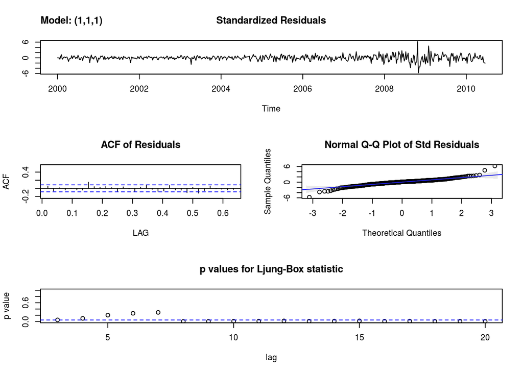

```r
sarima(oil, 1, 1, 1) -> oil_fit
```

```r
oil_fit$ttable
```

```
##          Estimate     SE t.value p.value
## ar1        0.8739 0.0600 14.5683  0.0000
## ma1       -0.7702 0.0779 -9.8897  0.0000
## constant   0.0629 0.1968  0.3198  0.7493
```

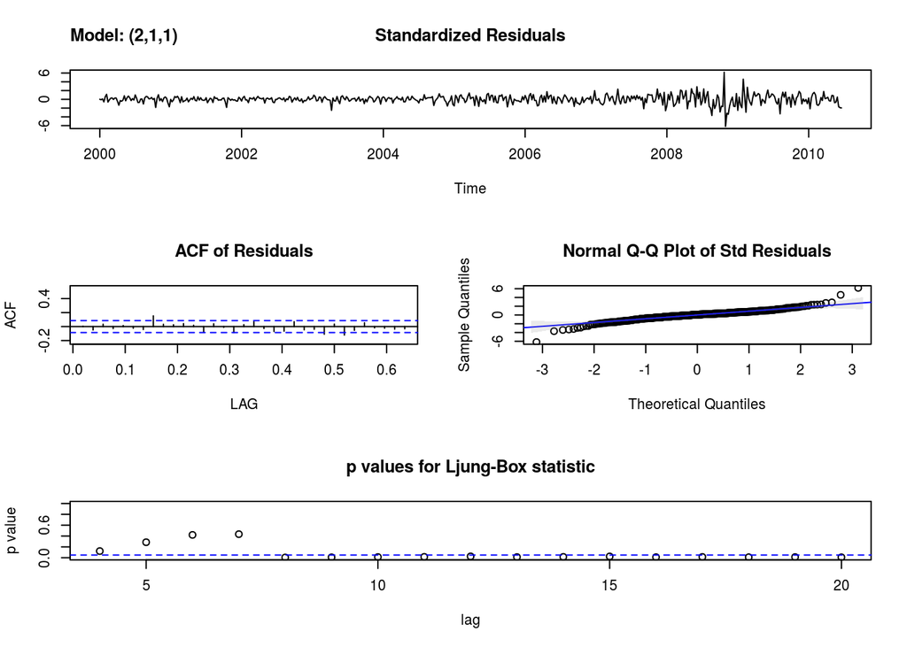

```r
sarima(oil, 2, 1, 1) -> oil_fit
```

```r
oil_fit$ttable
```

```
##          Estimate     SE  t.value p.value
## ar1        0.9715 0.0785  12.3792  0.0000
## ar2       -0.0705 0.0486  -1.4511  0.1473
## ma1       -0.8194 0.0649 -12.6171  0.0000
## constant   0.0642 0.1966   0.3267  0.7440
```

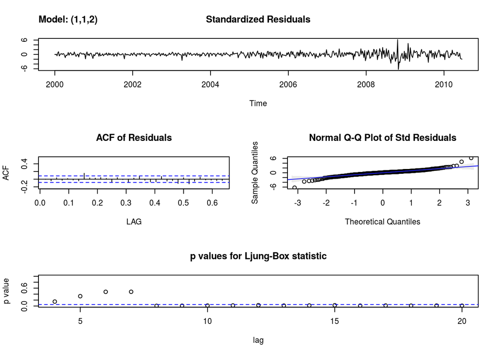

```r
sarima(oil, 1, 1, 2) -> oil_fit
```

```r
oil_fit$ttable
```

```
##          Estimate     SE  t.value p.value
## ar1        0.8933 0.0488  18.2933  0.0000
## ma1       -0.7330 0.0662 -11.0722  0.0000
## ma2       -0.0725 0.0465  -1.5597  0.1194
## constant   0.0643 0.1964   0.3276  0.7434
```

## Forecasting ARIMA Process

**astsa** has a function, `sarima.for()` which can be used to construct forecasts.

Forecasting becomes “easy” once the model is determined, just keep applying it going forward in time!

Here is an example with the *oil* dataset. the **ARIMA(1,1,1)** was determined the best model earlier.

```r
oil5 <- window(oil, end=2006)
oilf <- window(oil, end=2007)

sarima.for(oil5, n.ahead=52, 1, 1, 1)
```

```
## $pred
## Time Series:
## Start = c(2006, 2)
## End = c(2007, 1)
## Frequency = 52
##  [1] 60.71882 60.43909 60.74214 60.75455 60.91190 60.99696 61.11808
##  [8] 61.22122 61.33332 61.44095 61.55081 61.65956 61.76887 61.87790
## [15] 61.98706 62.09616 62.20529 62.31441 62.42353 62.53265 62.64177
## [22] 62.75089 62.86001 62.96913 63.07825 63.18737 63.29649 63.40561
## [29] 63.51473 63.62385 63.73297 63.84209 63.95121 64.06033 64.16945
## [36] 64.27857 64.38769 64.49681 64.60593 64.71505 64.82417 64.93329
## [43] 65.04241 65.15153 65.26065 65.36977 65.47889 65.58801 65.69713
## [50] 65.80625 65.91537 66.02449
##
## $se
## Time Series:
## Start = c(2006, 2)
## End = c(2007, 1)
## Frequency = 52
##  [1]  1.430557  2.270997  2.776644  3.245575  3.636008  3.996918  4.323903
##  [8]  4.629671  4.915600  5.186193  5.443159  5.688620  5.923876  6.150160
## [15]  6.368398  6.579407  6.783853  6.982317  7.175292  7.363212  7.546454
## [22]  7.725351  7.900198  8.071258  8.238767  8.402937  8.563961  8.722013
## [29]  8.877251  9.029820  9.179855  9.327476  9.472797  9.615922  9.756948
## [36]  9.895965 10.033055 10.168297 10.301764 10.433524 10.563640 10.692173
## [43] 10.819180 10.944712 11.068821 11.191554 11.312955 11.433067 11.551931
## [50] 11.669584 11.786062 11.901401
```

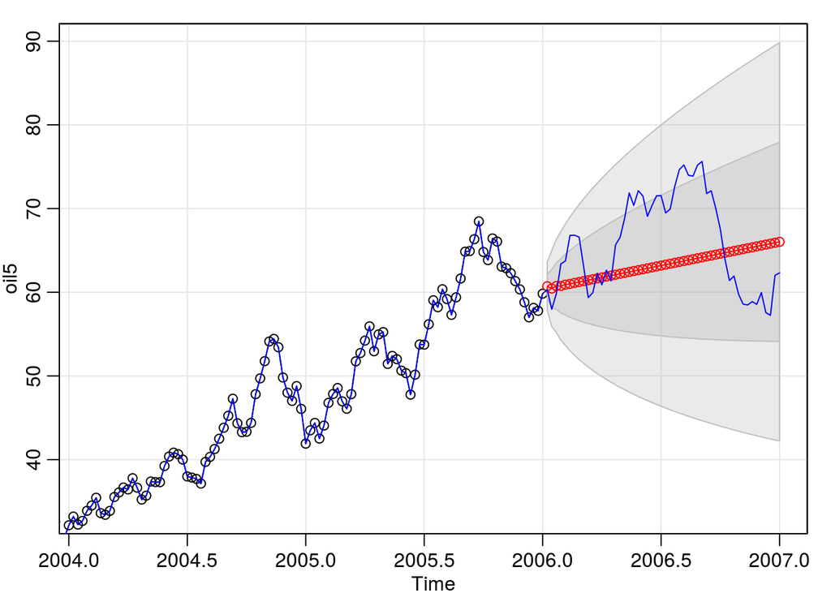

```r
lines(oilf, col='blue')
```